# SDS/CSC 293 Mini-Project 2: Multiple Regression

Group 4: Irene Ryan and Starry Zhou

Wednesday, March 6<sup>th</sup>, 2019

You will be submiting an entry to Kaggle’s [House Prices: Advanced Regression Techniques](https://www.kaggle.com/c/house-prices-advanced-regression-techniques/) by fitting a **multiple regression** model $\hat{f}(x)$.

# EDA

Read in data provided by Kaggle for this competition. They are organized in the `data/` folder of this RStudio project:

```r
training <- read_csv("data/train.csv")
test <- read_csv("data/test.csv")
sample_submission <- read_csv("data/sample_submission.csv")
```

Before performing any model fitting, you should always conduct an exploratory data analysis. This will help guide and inform your model fitting.

## Look at your data!

Always, ALWAYS, **ALWAYS** start by looking at your raw data. This gives you visual sense of what information you have to help build your predictive models. To get a full description of each variable, read the data dictionary in the `data_description.txt` file in the `data/` folder.

Note that the following code chunk has `eval = FALSE` meaning “don’t evaluate this chunk with knitting” because `.Rmd` files won’t knit if they include a `View()`:

```r
View(training)
glimpse(training)

View(test)
glimpse(test)
```

In particular, pay close attention to the variables and variable types in the `sample_submission.csv`. Your submission must match this exactly.

```r
glimpse(sample_submission)
```

```
## Observations: 1,459
## Variables: 2
## $ Id        <int> 1461, 1462, 1463, 1464, 1465, 1466, 1467, 1468, 1469, …
## $ SalePrice <dbl> 169277.1, 187758.4, 183583.7, 179317.5, 150730.1, 1771…
```

## Data wrangling

As much as possible, try to do all your data wrangling here:

```r
training_cv <- training %>%
  sample_frac(1) %>%
  mutate(fold = rep(1:5, length = n())) %>%
  arrange(fold)
```

# MVP/Due Diligence

## Visualizing Predictors

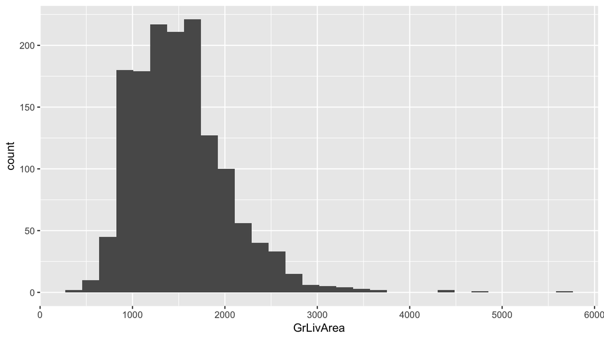

```r
ggplot(training, aes(x=GrLivArea))+
  geom_histogram()
```

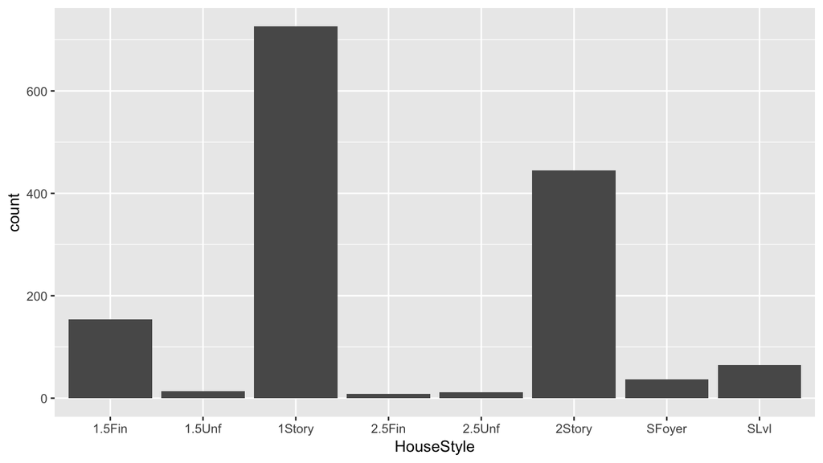

```r
ggplot(training, aes(x=HouseStyle))+
  geom_bar()
```

## Model fitting

```r
#first model: 1 numeric, 1 categorical
#Fit model to training
m1_formula <- as.formula("SalePrice~GrLivArea+HouseStyle")
m1 <- lm(m1_formula, data = training)

# make predictions on pretend test
fitted_points_m1 <- m1 %>%
  broom::augment()
head(fitted_points_m1)
```

| SalePrice | GrLivArea | HouseStyle | .fitted | .se.fit | .resid | .hat | .sigma | .cooksd | .std.resid |
| --- | --- | --- | --- | --- | --- | --- | --- | --- | --- |
| 208500 | 1710 | 2Story | 187006.9 | 2469.911 | 21493.0782 | 0.0023611 | 50845.36 | 0.0000471 | 0.4233343 |
| 181500 | 1262 | 1Story | 169932.5 | 1891.886 | 11567.5243 | 0.0013853 | 50847.59 | 0.0000080 | 0.2277262 |
| 223500 | 1786 | 2Story | 196878.9 | 2429.484 | 26621.0540 | 0.0022844 | 50843.68 | 0.0000699 | 0.5243164 |
| 140000 | 1717 | 2Story | 187916.2 | 2465.300 | -47916.1872 | 0.0023522 | 50832.89 | 0.0002333 | -0.9437679 |
| 250000 | 2198 | 2Story | 250395.7 | 2589.968 | -395.7087 | 0.0025962 | 50848.50 | 0.0000000 | -0.0077949 |
| 143000 | 1362 | 1.5Fin | 116754.8 | 4142.805 | 26245.2081 | 0.0066425 | 50843.80 | 0.0001994 | 0.5180466 |

```r
# make predictions on test set
predicted_points_m1 <- m1 %>%
  broom::augment(newdata = test)
head(predicted_points_m1)
```

| Id | MSSubClass | MSZoning | LotFrontage | LotArea | Street | Alley | LotShape | LandContour | Utilities | LotConfig | LandSlope | Neighborhood | Condition1 | Condition2 | BldgType | HouseStyle | OverallQual | OverallCond | YearBuilt | YearRemodAdd | RoofStyle | RoofMatl | Exterior1st | Exterior2nd | MasVnrType | MasVnrArea | ExterQual | ExterCond | Foundation | … |
| --- | --- | --- | --- | --- | --- | --- | --- | --- | --- | --- | --- | --- | --- | --- | --- | --- | --- | --- | --- | --- | --- | --- | --- | --- | --- | --- | --- | --- | --- | --- |
| 1461 | 20 | RH | 80 | 11622 | Pave | NA | Reg | Lvl | AllPub | Inside | Gtl | NAmes | Feedr | Norm | 1Fam | 1Story | 5 | 6 | 1961 | 1961 | Gable | CompShg | VinylSd | VinylSd | None | 0 | TA | TA | CBlock | … |
| 1462 | 20 | RL | 81 | 14267 | Pave | NA | IR1 | Lvl | AllPub | Corner | Gtl | NAmes | Norm | Norm | 1Fam | 1Story | 6 | 6 | 1958 | 1958 | Hip | CompShg | Wd Sdng | Wd Sdng | BrkFace | 108 | TA | TA | CBlock | … |
| 1463 | 60 | RL | 74 | 13830 | Pave | NA | IR1 | Lvl | AllPub | Inside | Gtl | Gilbert | Norm | Norm | 1Fam | 2Story | 5 | 5 | 1997 | 1998 | Gable | CompShg | VinylSd | VinylSd | None | 0 | TA | TA | PConc | … |
| 1464 | 60 | RL | 78 | 9978 | Pave | NA | IR1 | Lvl | AllPub | Inside | Gtl | Gilbert | Norm | Norm | 1Fam | 2Story | 6 | 6 | 1998 | 1998 | Gable | CompShg | VinylSd | VinylSd | BrkFace | 20 | TA | TA | PConc | … |
| 1465 | 120 | RL | 43 | 5005 | Pave | NA | IR1 | HLS | AllPub | Inside | Gtl | StoneBr | Norm | Norm | TwnhsE | 1Story | 8 | 5 | 1992 | 1992 | Gable | CompShg | HdBoard | HdBoard | None | 0 | Gd | TA | PConc | … |
| 1466 | 60 | RL | 75 | 10000 | Pave | NA | IR1 | Lvl | AllPub | Corner | Gtl | Gilbert | Norm | Norm | 1Fam | 2Story | 6 | 5 | 1993 | 1994 | Gable | CompShg | HdBoard | HdBoard | None | 0 | TA | TA | PConc | … |

## Estimate of your Kaggle score

```r
rmsle1<- rmsle(fitted_points_m1$SalePrice, fitted_points_m1$.fitted)
rmsle1
```

```
## [1] 0.2481358
```

## Create your submission CSV

```r
submission1 <- predicted_points_m1 %>%
  dplyr::select(Id, .fitted)
names(submission1)[2] <- "SalePrice"
write_csv(submission1, path = "data/submission_mvp.csv")
```

## Screenshot of your Kaggle score

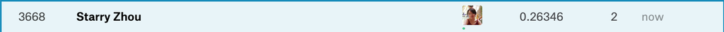

# Reaching for the stars

## Model fitting

```r
#second model: 3 numeric, 3 categorical

m2_formula <- as.formula("SalePrice~GrLivArea+ HouseStyle+ YrSold+ OverallCond+ LotConfig+ CentralAir")
m2 <- lm(m2_formula, data = training)

fitted_points_m2 <- m2 %>%
  broom::augment()
head(fitted_points_m2)
```

| SalePrice | GrLivArea | HouseStyle | YrSold | OverallCond | LotConfig | CentralAir | .fitted | .se.fit | .resid | .hat | .sigma | .cooksd | .std.resid |
| --- | --- | --- | --- | --- | --- | --- | --- | --- | --- | --- | --- | --- | --- |
| 208500 | 1710 | 2Story | 2008 | 5 | Inside | Y | 189336.7 | 2662.612 | 19163.251 | 0.0029097 | 49375.11 | 0.0000276 | 0.3887958 |
| 181500 | 1262 | 1Story | 2007 | 8 | FR2 | Y | 176948.8 | 8072.915 | 4551.238 | 0.0267485 | 49377.55 | 0.0000150 | 0.0934623 |
| 223500 | 1786 | 2Story | 2008 | 5 | Inside | Y | 198906.0 | 2621.767 | 24594.036 | 0.0028212 | 49373.44 | 0.0000440 | 0.4989567 |
| 140000 | 1717 | 2Story | 2006 | 5 | Corner | Y | 185005.1 | 4162.242 | -45005.138 | 0.0071104 | 49363.38 | 0.0003747 | -0.9150213 |
| 250000 | 2198 | 2Story | 2008 | 5 | FR2 | Y | 253811.7 | 7569.335 | -3811.667 | 0.0235155 | 49377.59 | 0.0000092 | -0.0781451 |
| 143000 | 1362 | 1.5Fin | 2009 | 5 | Inside | Y | 122768.2 | 4519.342 | 20231.827 | 0.0083828 | 49374.80 | 0.0000895 | 0.4116069 |

```r
predicted_points_m2 <- m2 %>%
  broom::augment(newdata = test)
head(predicted_points_m2)
```

| Id | MSSubClass | MSZoning | LotFrontage | LotArea | Street | Alley | LotShape | LandContour | Utilities | LotConfig | LandSlope | Neighborhood | Condition1 | Condition2 | BldgType | HouseStyle | OverallQual | OverallCond | YearBuilt | YearRemodAdd | RoofStyle | RoofMatl | Exterior1st | Exterior2nd | MasVnrType | MasVnrArea | ExterQual | ExterCond | Foundation | … |
| --- | --- | --- | --- | --- | --- | --- | --- | --- | --- | --- | --- | --- | --- | --- | --- | --- | --- | --- | --- | --- | --- | --- | --- | --- | --- | --- | --- | --- | --- | --- |
| 1461 | 20 | RH | 80 | 11622 | Pave | NA | Reg | Lvl | AllPub | Inside | Gtl | NAmes | Feedr | Norm | 1Fam | 1Story | 5 | 6 | 1961 | 1961 | Gable | CompShg | VinylSd | VinylSd | None | 0 | TA | TA | CBlock | … |
| 1462 | 20 | RL | 81 | 14267 | Pave | NA | IR1 | Lvl | AllPub | Corner | Gtl | NAmes | Norm | Norm | 1Fam | 1Story | 6 | 6 | 1958 | 1958 | Hip | CompShg | Wd Sdng | Wd Sdng | BrkFace | 108 | TA | TA | CBlock | … |
| 1463 | 60 | RL | 74 | 13830 | Pave | NA | IR1 | Lvl | AllPub | Inside | Gtl | Gilbert | Norm | Norm | 1Fam | 2Story | 5 | 5 | 1997 | 1998 | Gable | CompShg | VinylSd | VinylSd | None | 0 | TA | TA | PConc | … |
| 1464 | 60 | RL | 78 | 9978 | Pave | NA | IR1 | Lvl | AllPub | Inside | Gtl | Gilbert | Norm | Norm | 1Fam | 2Story | 6 | 6 | 1998 | 1998 | Gable | CompShg | VinylSd | VinylSd | BrkFace | 20 | TA | TA | PConc | … |
| 1465 | 120 | RL | 43 | 5005 | Pave | NA | IR1 | HLS | AllPub | Inside | Gtl | StoneBr | Norm | Norm | TwnhsE | 1Story | 8 | 5 | 1992 | 1992 | Gable | CompShg | HdBoard | HdBoard | None | 0 | Gd | TA | PConc | … |
| 1466 | 60 | RL | 75 | 10000 | Pave | NA | IR1 | Lvl | AllPub | Corner | Gtl | Gilbert | Norm | Norm | 1Fam | 2Story | 6 | 5 | 1993 | 1994 | Gable | CompShg | HdBoard | HdBoard | None | 0 | TA | TA | PConc | … |

## Estimate of your Kaggle score

```r
rmsle2 <- rmsle(fitted_points_m2$SalePrice, fitted_points_m2$.fitted)
rmsle2
```

```
## [1] 0.2640316
```

## Create your submission CSV

```r
submission2 <- predicted_points_m2 %>%
  dplyr::select(Id, .fitted)
names(submission2)[2] <- "SalePrice"
write_csv(submission2, path = "data/submission_reach_for_stars.csv")
```

## Screenshot of your Kaggle score

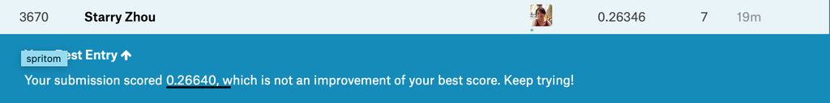

# Point of diminishing returns

## Model fitting

```r
#stepwise regression model: backwards selection on second model
m3 <- step(m2, direction = "backward")
```

```
## Start:  AIC=31572.08
## SalePrice ~ GrLivArea + HouseStyle + YrSold + OverallCond + LotConfig +
##     CentralAir
##
##               Df  Sum of Sq        RSS   AIC
## - YrSold       1 1.4065e+08 3.5184e+12 31570
## - OverallCond  1 4.5722e+08 3.5187e+12 31570
## <none>                      3.5183e+12 31572
## - LotConfig    4 4.3647e+10 3.5619e+12 31582
## - CentralAir   1 1.6953e+11 3.6878e+12 31639
## - HouseStyle   7 6.6402e+11 4.1823e+12 31811
## - GrLivArea    1 4.1494e+12 7.6677e+12 32707
##
## Step:  AIC=31570.14
## SalePrice ~ GrLivArea + HouseStyle + OverallCond + LotConfig +
##     CentralAir
##
##               Df  Sum of Sq        RSS   AIC
## - OverallCond  1 4.3436e+08 3.5188e+12 31568
## <none>                      3.5184e+12 31570
## - LotConfig    4 4.3623e+10 3.5620e+12 31580
## - CentralAir   1 1.6980e+11 3.6882e+12 31637
## - HouseStyle   7 6.6388e+11 4.1823e+12 31809
## - GrLivArea    1 4.1523e+12 7.6707e+12 32706
##
## Step:  AIC=31568.32
## SalePrice ~ GrLivArea + HouseStyle + LotConfig + CentralAir
##
##              Df  Sum of Sq        RSS   AIC
## <none>                     3.5188e+12 31568
## - LotConfig   4 4.3687e+10 3.5625e+12 31578
## - CentralAir  1 1.7736e+11 3.6962e+12 31638
## - HouseStyle  7 6.8262e+11 4.2015e+12 31813
## - GrLivArea   1 4.2216e+12 7.7404e+12 32717
```

```r
#view regression information
summary(m3)
```

```
##
## Call:
## lm(formula = SalePrice ~ GrLivArea + HouseStyle + LotConfig +
##     CentralAir, data = training)
##
## Residuals:
##     Min      1Q  Median      3Q     Max
## -518504  -21995   -2009   19147  300665
##
## Coefficients:
##                    Estimate Std. Error t value Pr(>|t|)
## (Intercept)      -99869.330   7972.655 -12.526  < 2e-16 ***
## GrLivArea           125.748      3.019  41.651  < 2e-16 ***
## HouseStyle1.5Unf  59992.083  13934.351   4.305 1.78e-05 ***
## HouseStyle1Story  61368.353   4470.829  13.726  < 2e-16 ***
## HouseStyle2.5Fin -83254.120  18305.064  -4.548 5.86e-06 ***
## HouseStyle2.5Unf  -3693.357  15713.208  -0.235   0.8142
## HouseStyle2Story  22303.442   4721.634   4.724 2.54e-06 ***
## HouseStyleSFoyer  57989.677   9285.510   6.245 5.55e-10 ***
## HouseStyleSLvl    40264.164   7378.821   5.457 5.70e-08 ***
## LotConfigCulDSac  24675.467   5971.680   4.132 3.80e-05 ***
## LotConfigFR2       8535.958   7856.331   1.087   0.2774
## LotConfigFR3      26507.980  24870.245   1.066   0.2867
## LotConfigInside    5624.352   3414.222   1.647   0.0997 .
## CentralAirY       46600.174   5458.459   8.537  < 2e-16 ***
## ---
## Signif. codes:  0 '***' 0.001 '**' 0.01 '*' 0.05 '.' 0.1 ' ' 1
##
## Residual standard error: 49330 on 1446 degrees of freedom
## Multiple R-squared:  0.6178, Adjusted R-squared:  0.6144
## F-statistic: 179.8 on 13 and 1446 DF,  p-value: < 2.2e-16
```

```r
# extract prediction
fitted_points_m3 <- m3 %>%
  broom::augment()
head(fitted_points_m3)
```

| SalePrice | GrLivArea | HouseStyle | LotConfig | CentralAir | .fitted | .se.fit | .resid | .hat | .sigma | .cooksd | .std.resid |
| --- | --- | --- | --- | --- | --- | --- | --- | --- | --- | --- | --- |
| 208500 | 1710 | 2Story | Inside | Y | 189687.6 | 2557.945 | 18812.445 | 0.0026888 | 49345.06 | 0.0000281 | 0.3818691 |
| 181500 | 1262 | 1Story | FR2 | Y | 175329.0 | 7323.936 | 6170.988 | 0.0220424 | 49347.27 | 0.0000258 | 0.1264968 |
| 223500 | 1786 | 2Story | Inside | Y | 199244.4 | 2523.578 | 24255.604 | 0.0026170 | 49343.41 | 0.0000454 | 0.4923407 |
| 140000 | 1717 | 2Story | Corner | Y | 184943.4 | 3699.222 | -44943.439 | 0.0056233 | 49333.30 | 0.0003372 | -0.9136408 |
| 250000 | 2198 | 2Story | FR2 | Y | 253964.1 | 7557.944 | -3964.140 | 0.0234734 | 49347.43 | 0.0000114 | -0.0813189 |
| 143000 | 1362 | 1.5Fin | Inside | Y | 123623.8 | 4142.488 | 19376.158 | 0.0070517 | 49344.89 | 0.0000788 | 0.3941749 |

```r
# make predictions on test set
predicted_points_m3 <- m3 %>%
  broom::augment(newdata = test)
head(predicted_points_m3)
```

| Id | MSSubClass | MSZoning | LotFrontage | LotArea | Street | Alley | LotShape | LandContour | Utilities | LotConfig | LandSlope | Neighborhood | Condition1 | Condition2 | BldgType | HouseStyle | OverallQual | OverallCond | YearBuilt | YearRemodAdd | RoofStyle | RoofMatl | Exterior1st | Exterior2nd | MasVnrType | MasVnrArea | ExterQual | ExterCond | Foundation | … |
| --- | --- | --- | --- | --- | --- | --- | --- | --- | --- | --- | --- | --- | --- | --- | --- | --- | --- | --- | --- | --- | --- | --- | --- | --- | --- | --- | --- | --- | --- | --- |
| 1461 | 20 | RH | 80 | 11622 | Pave | NA | Reg | Lvl | AllPub | Inside | Gtl | NAmes | Feedr | Norm | 1Fam | 1Story | 5 | 6 | 1961 | 1961 | Gable | CompShg | VinylSd | VinylSd | None | 0 | TA | TA | CBlock | … |
| 1462 | 20 | RL | 81 | 14267 | Pave | NA | IR1 | Lvl | AllPub | Corner | Gtl | NAmes | Norm | Norm | 1Fam | 1Story | 6 | 6 | 1958 | 1958 | Hip | CompShg | Wd Sdng | Wd Sdng | BrkFace | 108 | TA | TA | CBlock | … |
| 1463 | 60 | RL | 74 | 13830 | Pave | NA | IR1 | Lvl | AllPub | Inside | Gtl | Gilbert | Norm | Norm | 1Fam | 2Story | 5 | 5 | 1997 | 1998 | Gable | CompShg | VinylSd | VinylSd | None | 0 | TA | TA | PConc | … |
| 1464 | 60 | RL | 78 | 9978 | Pave | NA | IR1 | Lvl | AllPub | Inside | Gtl | Gilbert | Norm | Norm | 1Fam | 2Story | 6 | 6 | 1998 | 1998 | Gable | CompShg | VinylSd | VinylSd | BrkFace | 20 | TA | TA | PConc | … |
| 1465 | 120 | RL | 43 | 5005 | Pave | NA | IR1 | HLS | AllPub | Inside | Gtl | StoneBr | Norm | Norm | TwnhsE | 1Story | 8 | 5 | 1992 | 1992 | Gable | CompShg | HdBoard | HdBoard | None | 0 | Gd | TA | PConc | … |
| 1466 | 60 | RL | 75 | 10000 | Pave | NA | IR1 | Lvl | AllPub | Corner | Gtl | Gilbert | Norm | Norm | 1Fam | 2Story | 6 | 5 | 1993 | 1994 | Gable | CompShg | HdBoard | HdBoard | None | 0 | TA | TA | PConc | … |

## Estimate of your Kaggle score

```r
rmsle3 <- rmsle(fitted_points_m3$SalePrice, fitted_points_m3$.fitted)
rmsle3
```

```
## [1] 0.279053
```

## Create your submission CSV

```r
submission3 <- predicted_points_m3 %>%
  dplyr::select(Id, .fitted)
names(submission3)[2] <- "SalePrice"
write_csv(submission3, path = "data/submission_diminishing_returns.csv")
```

## Screenshot of your Kaggle score

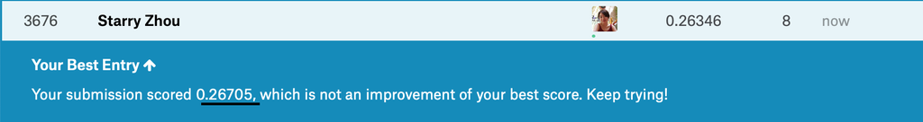

# Comparisons of estimated scores and Kaggle scores

Model 1: Our score based on our submission’s “Root Mean Squared Logarithmic Error” was .26. Our estimated RMSLE is $.25$.

$RMSLE_1 = .26$

$\widehat{RMSLE_1} = .25$

Model 3: Our score based on our submission’s “Root Mean Squared Logarithmic Error” was $.267$. The estimated RMSLE is $.279$.

$RMSLE_3 = .267$ $\widehat{RMSLE_3} = .279$